# Anglophone vs. Non-Anglophone Movies: Comparisons Within and Between.

Klara Thelusma, Maya Anderson, Pedro Gallardo Nascimento, Colin Nguyen

## Introduction

With an increasingly interconnected world, some movies exist in multiple languages so that they could be distributed in different nations across the world. However, with being shown in various countries with unique cultures and varying values, a question arises: does the language and region that a movie is in affect its reception? Using the IMDB dataset that includes thousands of movies and their data, our group wants to answer this question by analyzing variables such as language, region, and genre. In the contemporary use of the data, we must acknowledge that the predictions and patterns that we may find aren’t all-encompassing or consistently accurate; as we know, society has changed over time, and so the findings we uncover in this age may not be wholly applicable to a past time, or even the future.

## Database Design

The database is structured by using titleId to bridge information across different tables. The database also includes many copies of the same movies, with the subtle differences being in the differences of the language that the specific version is marketed in, or the original title. We will be paying close attention to these copies in different languages as we want to see if the language and region that a movie is released in affects its ratings. The information regarding region is also important to see if a genre performs the same across the world, or if certain regions prefer one genre over the other. This approach allows us to easily compare the reception of certain movies and their genres in different regions as there are multiple copies of the same movie to compare each other to, rather than having the confounding variable of the ratings being affected by the movie itself and not its genre.

## Data Exploration

For the following four boxplot graphs, we decided to simplify things and look at the five biggest language groups (English, Spanish, Mandarin Chinese, Hindi, and Arabic). This is just an initial look-through, and since all of these language come from different cultures, we believe that it will provide some insight at how culture affects ratings.

```python
import pandas as pd
import matplotlib.pyplot as plt
import sqlite3
import seaborn as sns

conn = sqlite3.connect('data/imdb_full.db')
c = conn.cursor()
```

```
[Text(0.5, 1.0, 'The Distribution of the Average Ratings for Movies \n in Various Spanish-Speaking Countries')]
```

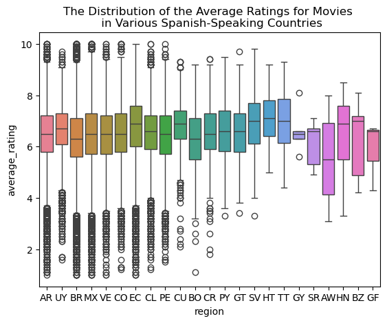

```python
#Spanish-speaking countries SOURCE: https://www.nro.net/list-of-country-codes-in-the-lacnic-region/
query = "SELECT ratings.averageRating AS average_ratings, title_akas.region AS region FROM title_akas LEFT JOIN ratings ON ratings.titleId=title_akas.titleId WHERE region IN ('AR','AW','BZ','BO','BR','CL','CO','CR','CU','EC','SV','FK','GF','GT','GY','HT','HN','MX','PY','PE','SR','TT','UY','VE')"
display = c.execute(query).fetchall()

spanish_df = pd.DataFrame(display, columns= ['average_rating', 'region'])

plot1 = sns.boxplot(data=spanish_df, x='region', y='average_rating', hue = "region")
plot1.set(title = 'The Distribution of the Average Ratings for Movies \n in Various Spanish-Speaking Countries')
```

This series of boxplots show that the rating medians for movies in Spanish-speaking countries are mostly above 6, with only outliers going below the three-level rating; we'll be comparing these ratings to other language groups to see if they are stricter in rating movies or not. Also, it's notable that most countries have only outliers in the 10-rating range, so this may imply that there's some strictness in reception of movies. It also may show us some insight in how certain language groups give out ratings- perhaps ten is reserved only for perfect movies, and the six-level range is considered average.

```
[Text(0.5, 1.0, 'The Distribution of the Average Ratings for Movies \n in Various English-Speaking Countries')]
```

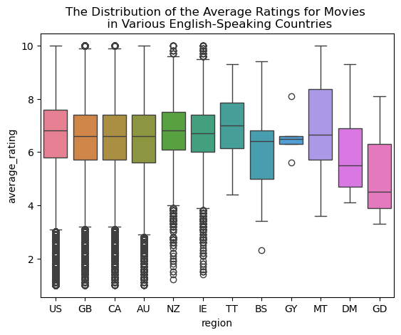

```python
#Majority English-speaking countries SOURCES: https://www.sheffield.ac.uk/international/english-speaking-countries  &  https://www.iban.com/country-codes
query2 = "SELECT ratings.averageRating AS average_ratings, title_akas.region AS region FROM title_akas LEFT JOIN ratings ON ratings.titleId=title_akas.titleId WHERE region IN ('US','GB','AU','BS','CA','DM','GD','GY','IE','MT','NZ','TT')"
display2 = c.execute(query2).fetchall()

english_df = pd.DataFrame(display2, columns= ['average_rating', 'region'])

plot2 = sns.boxplot(data=english_df, x='region', y='average_rating', hue = "region")
plot2.set(title = 'The Distribution of the Average Ratings for Movies \n in Various English-Speaking Countries')
```

In comparison to Spanish speakers, the distributions for movie ratings for English-language movies seem pretty similar; many medians are above the 6-level with most boxplots having only outliers at or slightly below three. Howver, compared to the Spanish boxplots, ten-level ratings seemed to be given out more commonly; perhaps this hints that English-speaking countries are less harsh when rating movies, or that they percieve the 1-10 rating scale a bit differently.

```
[Text(0.5, 1.0, 'The Distribution of the Average Ratings for Movies \n in Various Hindi and Chinese-Speaking Countries')]
```

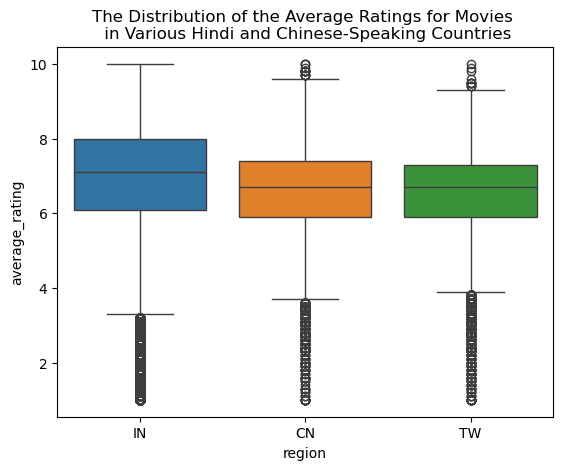

```python
#Majority English-speaking countries SOURCES: https://www.sheffield.ac.uk/international/english-speaking-countries  &  https://www.iban.com/country-codes
query3 = "SELECT ratings.averageRating AS average_ratings, title_akas.region AS region FROM title_akas LEFT JOIN ratings ON ratings.titleId=title_akas.titleId WHERE region IN ('IN', 'CN', 'TW')"
display3 = c.execute(query3).fetchall()

hindi_df = pd.DataFrame(display3, columns= ['average_rating', 'region'])

plot3 = sns.boxplot(data=hindi_df, x='region', y='average_rating', hue = "region")
plot3.set(title = 'The Distribution of the Average Ratings for Movies \n in Various Hindi and Chinese-Speaking Countries')
```

Since there aren't as many countries that mainly speak Mandarin Chinese and Hindi, I combined both language groups in to one graph to save space. Hindi's rating distribution (indicated by IN for India) seems to be the highest scores that we've seen so far; 50% of their ratings are between 6 and 8. 25% of their movies are between 8 and 10; maybe Hindi viewers are the most lenient/least picky when it comes to rating movies. For Chinese-speaking countries (China and Taiwan), they look pretty similar to each other. In comparison to earlier boxplots, they seem to be less strict in giving out high-ratings than Spanish-speaking viewers but more strict than English-speaking viewers.

```
[Text(0.5, 1.0, 'The Distribution of the Average Ratings for Movies \n in Various Arabic-Speaking Countries')]
```

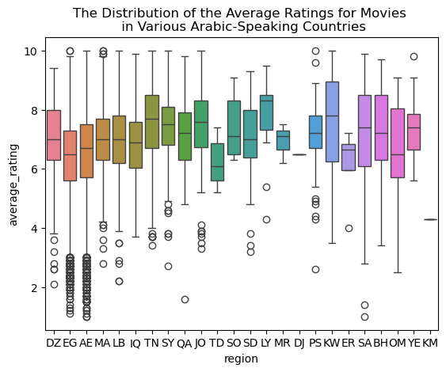

```python
query4 = "SELECT ratings.averageRating AS average_ratings, title_akas.region AS region FROM title_akas LEFT JOIN ratings ON ratings.titleId=title_akas.titleId WHERE region IN ('OM', 'JO', 'DZ', 'LY', 'MR', 'BH', 'IQ', 'KM', 'PS', 'SA', 'KW', 'SY', 'MA', 'TD', 'QA', 'AE', 'EG', 'SD', 'LB', 'TN', 'SO', 'DJ', 'YE', 'ER')"
display4 = c.execute(query4).fetchall()

chinese_df = pd.DataFrame(display4, columns= ['average_rating', 'region'])

plot4 = sns.boxplot(data=chinese_df, x='region', y='average_rating', hue = "region")
plot4.set(title = 'The Distribution of the Average Ratings for Movies \n in Various Arabic-Speaking Countries')
```

For Arabic-speaking countries, there's noticeably a lot more variation in the distribution of ratings; countries included here come from both Africa and Asia (two vastly different continents with completely unique cultures) so that may play a role in this variation. It's also interesting to see how some countries' highest ratings don't even break an 8; this could be because there's not many movies available in these languages, but it could also hint that there's a certain level of strictness and harshness towards movies as seen from the low ratings.

```
[Text(0.5, 1.0, 'The Distribution of the Average Ratings for Different Movie Genres \n in Various English-Speaking Countries')]
```

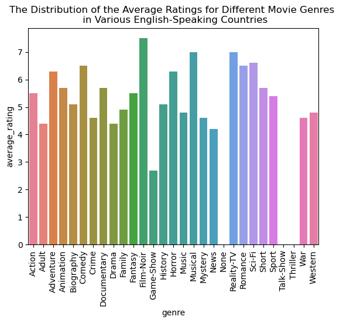

```python
query3 = "SELECT ratings.averageRating AS high_rating, title_akas.region AS region, genres.genre AS genre FROM title_akas LEFT JOIN genres ON genres.titleId=title_akas.titleId LEFT JOIN ratings ON ratings.titleId=title_akas.titleId WHERE region IN ('US','GB','AU','BS','CA','DM','GD','GY','IE','MT','NZ','TT') GROUP BY genre"
display3 = c.execute(query3).fetchall()

display3_df = pd.DataFrame(display3, columns= ['average_rating', 'region', 'genre'])

plot3 = sns.barplot(data=display3_df, x='genre', y='average_rating', hue = "genre", legend=False)
plot3.set_xticks([0, 1, 2, 3, 4, 5, 6, 7, 8, 9, 10, 11, 12, 13, 14, 15, 16, 17, 18, 19, 20, 21, 22, 23, 24, 25, 26, 27, 28])
plot3.set_xticklabels(labels=["Action", "Adult", "Adventure", "Animation", "Biography", "Comedy", "Crime", "Documentary", "Drama", "Family", "Fantasy", "Film-Noir", "Game-Show", "History", "Horror", "Music", "Musical", "Mystery", "News", "None", "Reality-TV", "Romance", "Sci-Fi", "Short", "Sport", "Talk-Show", "Thriller", "War", "Western"], rotation=90)
plot3.set(title = 'The Distribution of the Average Ratings for Different Movie Genres \n in Various English-Speaking Countries')
```

```
[Text(0.5, 1.0, 'The Distribution of the Average Ratings for Different Movie Genres \n in Various Non-English Speaking Countries')]
```

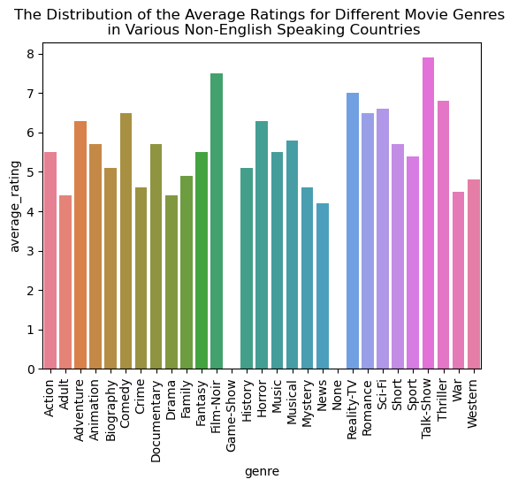

```python
query4 = "SELECT ratings.averageRating AS high_rating, title_akas.region AS region, genres.genre AS genre FROM title_akas LEFT JOIN genres ON genres.titleId=title_akas.titleId LEFT JOIN ratings ON ratings.titleId=title_akas.titleId WHERE region NOT IN ('US','GB','AU','BS','CA','DM','GD','GY','IE','MT','NZ','TT') GROUP BY genre"
display4 = c.execute(query4).fetchall()

display4_df = pd.DataFrame(display4, columns= ['average_rating', 'region', 'genre'])

plot4 = sns.barplot(data=display4_df, x='genre', y='average_rating', hue = "genre", legend=False)
plot4.set_xticks([0, 1, 2, 3, 4, 5, 6, 7, 8, 9, 10, 11, 12, 13, 14, 15, 16, 17, 18, 19, 20, 21, 22, 23, 24, 25, 26, 27, 28])
plot4.set_xticklabels(labels=["Action", "Adult", "Adventure", "Animation", "Biography", "Comedy", "Crime", "Documentary", "Drama", "Family", "Fantasy", "Film-Noir", "Game-Show", "History", "Horror", "Music", "Musical", "Mystery", "News", "None", "Reality-TV", "Romance", "Sci-Fi", "Short", "Sport", "Talk-Show", "Thriller", "War", "Western"], rotation=90)
plot4.set(title = 'The Distribution of the Average Ratings for Different Movie Genres \n in Various Non-English Speaking Countries')
```

To simplify the comparison, we reduced the groups down to English-speaking countries and non-English speaking countries. Ratings for different genres generally look like they follow similar trends in rating, with the exception of the exclusion of certain genres in non-English speaking viewers (game-show, none) and a much higher rating for talk-show and thriller (which don't exist in the English-speaking countries). Of course, if there was more time, we could go more in-depth in our analysis by looking into more specific regions in the non-English speaking world to see if there are any differences between them, but that would produce many more graphs and take up many more hours.

```python
## Table displaying the Regions and Region_count
query = "SELECT region, COUNT(*) AS region_count FROM title_akas GROUP BY region ORDER BY region_count DESC LIMIT 15"
rows = c.execute(query).fetchall()

# Convert the data to a pandas DataFrame
columns = ['region', 'region_count']
df = pd.DataFrame(rows, columns=columns)

# Display the DataFrame
print(df)
```

```
   region  region_count
0      DE       4616524
1      JP       4616176
2      FR       4613790
3      IN       4559054
4      ES       4532415
5      IT       4512291
6      PT       4434856
7    None       1914995
8      US       1491448
9      GB        468313
10     CA        253459
11    XWW        182367
12     AU        155575
13     BR        123804
14     RU        102902
```

In this section of code, we wrote SQL queries to fetch the top 100 most and least preferred genres based on average ratings for both English-speaking and non-English-speaking regions. We then executed these queries to generate DataFrames and visualized the genre distributions with bar plots, using distinct color palettes to differentiate between the most and least preferred genres across the two regional groups.

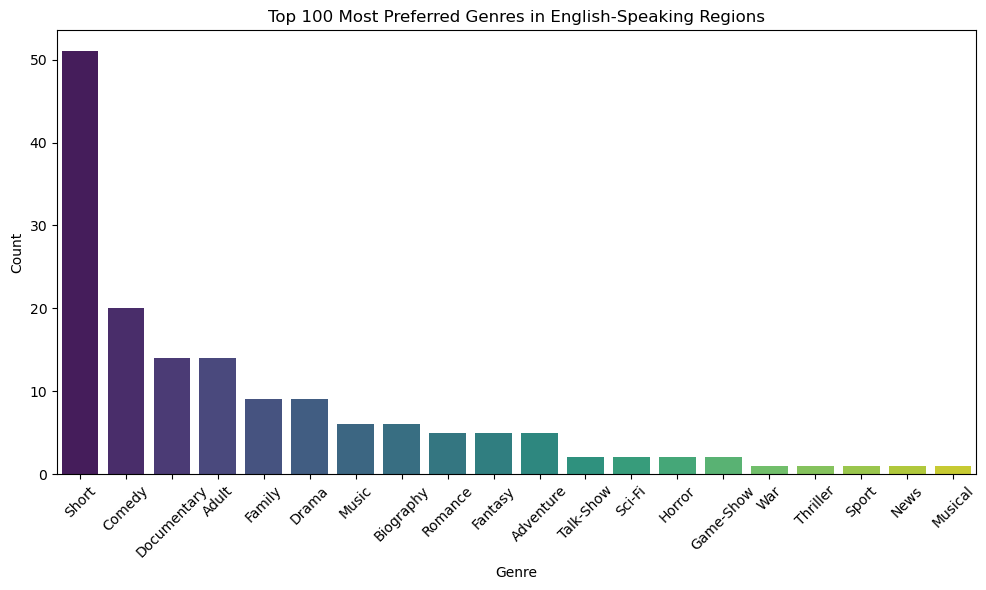

```python
# English-speaking regions
English_region = ('US', 'GB', 'AU', 'BS', 'CA', 'DM', 'GD', 'GY', 'IE', 'MT', 'NZ', 'TT')

# Query for 100 most preferred genres in English regions
query5_english_most = f"""
WITH MaxRatings AS (
    SELECT
        title_akas.titleId,
        title_akas.region,
        ratings.averageRating
    FROM
        title_akas
    JOIN
        ratings
    ON
        title_akas.titleId = ratings.titleId
    WHERE
        title_akas.region IN {English_region}
    ORDER BY
        ratings.averageRating DESC
    LIMIT 100
)
SELECT
    genres.genre,
    COUNT(*) AS genre_count
FROM
    MaxRatings
JOIN
    genres
ON
    MaxRatings.titleId = genres.titleId
GROUP BY
    genres.genre
ORDER BY
    genre_count DESC
"""

# Execute queries and convert to DataFrames
display3_english_most = c.execute(query5_english_most).fetchall()
genre_distribution_english_most_df = pd.DataFrame(display3_english_most, columns=['genre', 'genre_count'])

# Plot for 100 Most Preferred English regions
plt.figure(figsize=(10, 6))
sns.barplot(data=genre_distribution_english_most_df, x='genre', y='genre_count', palette='viridis')
plt.title('Top 100 Most Preferred Genres in English-Speaking Regions')
plt.xlabel('Genre')
plt.ylabel('Count')
plt.xticks(rotation=45)
plt.tight_layout()
plt.show()
```

For the top 100 most preferred genres in English-speaking regions, it's clear that a significant portion (over 50%) falls under the "Short" genre, followed by "Comedy," and then genres like "Documentary" and "Adult," which are similar in popularity. What stands out is the diversity in the other genres, highlighting a wide range of interests despite the dominance of these four genres. This suggests that, while certain genres may be more universally popular, there is still a broad spectrum of preferences among audiences in English-speaking regions.

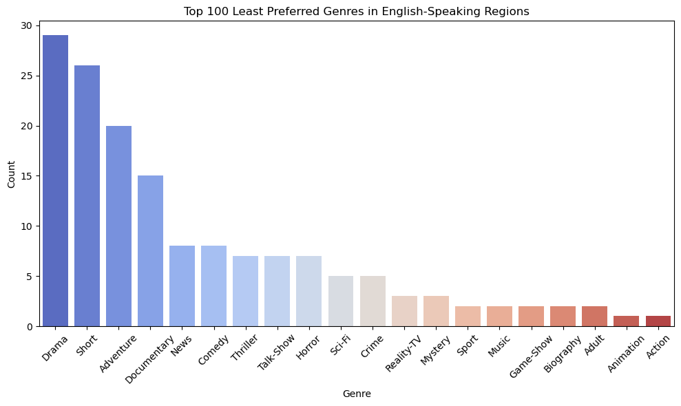

```python
# Query for 100 least preferred genres in English regions
query5_english_least = f"""
WITH MinRatings AS (
    SELECT
        title_akas.titleId,
        title_akas.region,
        ratings.averageRating
    FROM
        title_akas
    JOIN
        ratings
    ON
        title_akas.titleId = ratings.titleId
    WHERE
        title_akas.region IN {English_region}
    ORDER BY
        ratings.averageRating ASC
    LIMIT 100
)
SELECT
    genres.genre,
    COUNT(*) AS genre_count
FROM
    MinRatings
JOIN
    genres
ON
    MinRatings.titleId = genres.titleId
GROUP BY
    genres.genre
ORDER BY
    genre_count DESC
"""

display3_english_least = c.execute(query5_english_least).fetchall()
genre_distribution_english_least_df = pd.DataFrame(display3_english_least, columns=['genre', 'genre_count'])

# Plot for 100 Least Preferred English regions
plt.figure(figsize=(10, 6))
sns.barplot(data=genre_distribution_english_least_df, x='genre', y='genre_count', palette='coolwarm')
plt.title('Top 100 Least Preferred Genres in English-Speaking Regions')
plt.xlabel('Genre')
plt.ylabel('Count')
plt.xticks(rotation=45)
plt.tight_layout()
plt.show()
```

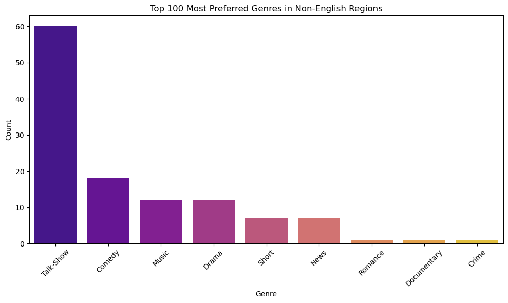

```python
# Query for 100 most preferred genres in Non-English regions
query5_non_english_most = """
WITH MaxRatings AS (
    SELECT
        title_akas.titleId,
        title_akas.region,
        ratings.averageRating
    FROM
        title_akas
    JOIN
        ratings
    ON
        title_akas.titleId = ratings.titleId
    WHERE
        title_akas.region NOT IN ('US', 'GB', 'AU', 'BS', 'CA', 'DM', 'GD', 'GY', 'IE', 'MT', 'NZ', 'TT')
    ORDER BY
        ratings.averageRating DESC
    LIMIT 100
)
SELECT
    genres.genre,
    COUNT(*) AS genre_count
FROM
    MaxRatings
JOIN
    genres
ON
    MaxRatings.titleId = genres.titleId
GROUP BY
    genres.genre
ORDER BY
    genre_count DESC
"""

display3_non_english_most = c.execute(query5_non_english_most).fetchall()
genre_distribution_non_english_most_df = pd.DataFrame(display3_non_english_most, columns=['genre', 'genre_count'])

# Plot for 100 Most Preferred Non-English regions
plt.figure(figsize=(10, 6))
sns.barplot(data=genre_distribution_non_english_most_df, x='genre', y='genre_count', palette='plasma')
plt.title('Top 100 Most Preferred Genres in Non-English Regions')
plt.xlabel('Genre')
plt.ylabel('Count')
plt.xticks(rotation=45)
plt.tight_layout()
plt.show()
```

For the top 100 most preferred genres in non-English regions, "Talk Shows" dominate by a significant margin, accounting for around 60%, followed by genres like "Comedy," "Music," "Drama," and "Short." Compared to English-speaking regions, there is much less diversity in genre preferences, indicating a more focused set of interests in the broader global context. This trend is intriguing, as it suggests that non-English audiences may have more concentrated tastes, potentially influenced by cultural and regional factors.

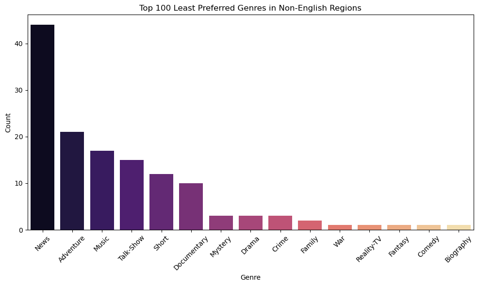

```python
# Query for 100 least preferred genres in Non-English regions
query5_non_english_least = """
WITH MinRatings AS (
    SELECT
        title_akas.titleId,
        title_akas.region,
        ratings.averageRating
    FROM
        title_akas
    JOIN
        ratings
    ON
        title_akas.titleId = ratings.titleId
    WHERE
        title_akas.region NOT IN ('US', 'GB', 'AU', 'BS', 'CA', 'DM', 'GD', 'GY', 'IE', 'MT', 'NZ', 'TT')
    ORDER BY
        ratings.averageRating ASC
    LIMIT 100
)
SELECT
    genres.genre,
    COUNT(*) AS genre_count
FROM
    MinRatings
JOIN
    genres
ON
    MinRatings.titleId = genres.titleId
GROUP BY
    genres.genre
ORDER BY
    genre_count DESC
"""

display3_non_english_least = c.execute(query5_non_english_least).fetchall()
genre_distribution_non_english_least_df = pd.DataFrame(display3_non_english_least, columns=['genre', 'genre_count'])

#Plot for 100 Least Preferred Non-English regions
plt.figure(figsize=(10, 6))
sns.barplot(data=genre_distribution_non_english_least_df, x='genre', y='genre_count', palette='magma')
plt.title('Top 100 Least Preferred Genres in Non-English Regions')
plt.xlabel('Genre')
plt.ylabel('Count')
plt.xticks(rotation=45)
plt.tight_layout()
plt.show()
```

For the top 100 least preferred genres in non-English-speaking regions, we see a strong preference for "News" and less overall genre variety. The distribution from the 2nd to 6th least liked genres follows a "staircase-like" linear pattern, showing a consistent decline in dislike across these genres. This could indicate a more uniform pattern of aversion across these genres, with few outliers. Interestingly, compared to the most preferred genres in the same region, there is more diversity in the genres, showcasing a wider range of dislikes, which suggests that people in non-English-speaking regions may be more nuanced in their disapproval compared to their preferences.

## Uses of Python: Technical Components

*Fill in the table below with information about how you satisfied the technical requirements of the assignment.*

[output not shown]

## Uses of Python: Reflection

*Take a step back and analyze your own use of code. Provide some rationale for choices you’ve made. Considerations may include performance, human readability, code dependencies, and reproducibility.*

In our code for this project, another key factor that we considered in our work was reversibility. As we read about and discussed in class, reversibility is key in working on a project, especially as a group. By attempting to make our code as reversible as was beneficial, we made our code more flexible to potential needed changes or updates, and also made our code more easy to work with in sync with each other as a group. Another benefit is that code that is reversible often tends to be more readable, since code that is able to be easily changed is more readable than code that is not reversible. An example of how we utilized reversibility is in our decision to create new variables or copies of our data frame rather than writing over the current one. This decision was influenced by our goal of reversibility since any potential change that needed to be made later in the code would not be hindered by the changed variable or data frame since the original is preserved. Another example is we generally attempted to make our code flat rather than nested, a strategy that makes our code generally more efficient and reversible through its avoidance of overcomplicating the code.

As we worked as a group, we were able to exercise multiple principles of debugging in order to make sure that our code would work smoothly. For example, we used rubber ducking between each other (especially when coding graphs) in order to check if the code we had separately would work together. This way, we were able to not only communicate to each other about what purpose each of our code serves, we were also able to see how each part of the code serves in the overall story of the data.

## References

*List all works cited in the data guide. Use proper APA format.*

University of Sheffield. (2019). Native English speaking countries - Prospective International students - The University of Sheffield. Sheffield.ac.uk. https://www.sheffield.ac.uk/international/english-speaking-countries

IBAN. (2019). List of country codes by alpha-2, alpha-3 code (ISO 3166). Iban.com. https://www.iban.com/country-codes

‌

‌